# R5 MARTINEZ

Martinez Francisco

11/12/2020

# Exercice 1.

For the data InsectSpray, make a table for the number of insects for each spray with the mean, median and standard error. Note: Remember to use knitr::kable(), or a similar function to print the table with its caption.

```r
me <- med <- se <- In <- numeric()
sp <- character()

for(i in levels(InsectSprays$spray)){   #i is a random value given to the spray column.
  for(j in names(InsectSprays)[-2]){    #j is a random value given to the count column.

    sp <-c(sp,i)                   # vector that allows to go through the values related to the levels of spray.

    x <- InsectSprays[InsectSprays$spray ==i,j]
    me <- round(c(me, mean(x)), 2)
    se <- round(c(se, sd(x) / sqrt(length(x))),2)
    med <- c(med, median(x))
    In <- c(In, sum(x))

  }
}

d <- data.frame(Spray  = sp,
                Insects_count = In,
                Mean = me,
                Standarderror = se,
                Median = med)
knitr::kable(d <- data.frame(Spray  = sp,
                Insects_count = In,
                Mean = me,
                Standarderror = se,
                Median = med)
, caption = "Table 1. The effect of spray on insect count")
```

Table 1. The effect of spray on insect count

| Spray | Insects_count | Mean | Standarderror | Median |
| --- | --- | --- | --- | --- |
| A | 174 | 14.50 | 1.36 | 14.0 |
| B | 184 | 15.33 | 1.23 | 16.5 |
| C | 25 | 2.08 | 0.57 | 1.5 |
| D | 59 | 4.92 | 0.72 | 5.0 |
| E | 42 | 3.50 | 0.50 | 3.0 |
| F | 200 | 16.67 | 1.79 | 15.0 |

# Exercice 2. Print a plot to see the differences of counts between sprays.

#Include a caption explaining the figure. Which type of plot is the one you choose and why?

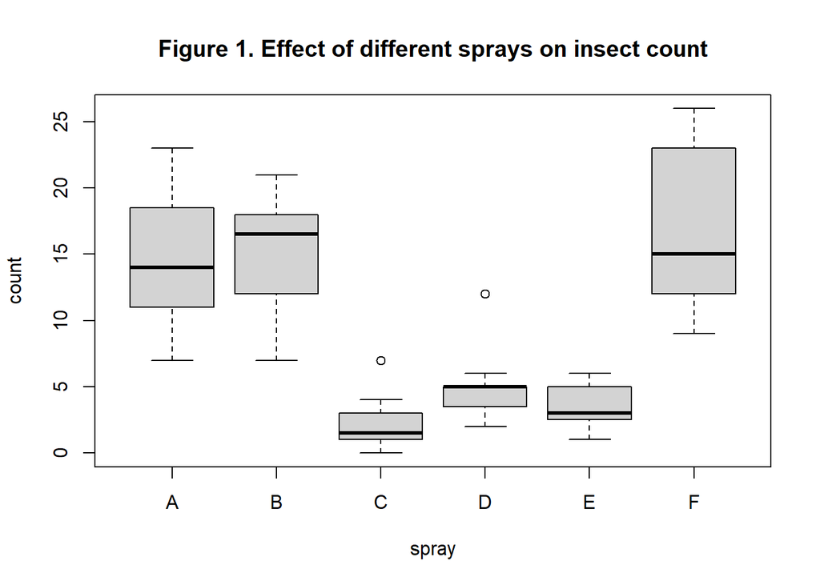

Figure 1. Effect of different sprays on insect count

```r
boxplot(count ~ spray, data = InsectSprays)
title(main="Figure 1. Effect of different sprays on insect count")
```

# Answer: I choosed boxplot because we can see the median,max and min values and the diversity of our data.

# Exercice 3. Test for differences between sprays using anova and a posthoc comparison.

```r
res.aov <- aov(count ~ spray, data = InsectSprays)
summary(res.aov)
```

```
##             Df Sum Sq Mean Sq F value Pr(>F)
## spray        5   2669   533.8    34.7 <2e-16 ***
## Residuals   66   1015    15.4
## ---
## Signif. codes:  0 '***' 0.001 '**' 0.01 '*' 0.05 '.' 0.1 ' ' 1
```

```r
tukey.test <- TukeyHSD(res.aov)
print(tukey.test)
```

```
##   Tukey multiple comparisons of means
##     95% family-wise confidence level
##
## Fit: aov(formula = count ~ spray, data = InsectSprays)
##
## $spray
##            diff        lwr       upr     p adj
## B-A   0.8333333  -3.866075  5.532742 0.9951810
## C-A -12.4166667 -17.116075 -7.717258 0.0000000
## D-A  -9.5833333 -14.282742 -4.883925 0.0000014
## E-A -11.0000000 -15.699409 -6.300591 0.0000000
## F-A   2.1666667  -2.532742  6.866075 0.7542147
## C-B -13.2500000 -17.949409 -8.550591 0.0000000
## D-B -10.4166667 -15.116075 -5.717258 0.0000002
## E-B -11.8333333 -16.532742 -7.133925 0.0000000
## F-B   1.3333333  -3.366075  6.032742 0.9603075
## D-C   2.8333333  -1.866075  7.532742 0.4920707
## E-C   1.4166667  -3.282742  6.116075 0.9488669
## F-C  14.5833333   9.883925 19.282742 0.0000000
## E-D  -1.4166667  -6.116075  3.282742 0.9488669
## F-D  11.7500000   7.050591 16.449409 0.0000000
## F-E  13.1666667   8.467258 17.866075 0.0000000
```

## install packages: agricolae

```r
library(agricolae)
letter_test <- HSD.test(res.aov, "spray")
letter_test
```

```
## $statistics
##    MSerror Df Mean       CV      MSD
##   15.38131 66  9.5 41.28318 4.699409
##
## $parameters
##    test name.t ntr StudentizedRange alpha
##   Tukey  spray   6         4.150851  0.05
##
## $means
##       count      std  r Min Max   Q25  Q50   Q75
## A 14.500000 4.719399 12   7  23 11.50 14.0 17.75
## B 15.333333 4.271115 12   7  21 12.50 16.5 17.50
## C  2.083333 1.975225 12   0   7  1.00  1.5  3.00
## D  4.916667 2.503028 12   2  12  3.75  5.0  5.00
## E  3.500000 1.732051 12   1   6  2.75  3.0  5.00
## F 16.666667 6.213378 12   9  26 12.50 15.0 22.50
##
## $comparison
## NULL
##
## $groups
##       count groups
## F 16.666667      a
## B 15.333333      a
## A 14.500000      a
## D  4.916667      b
## E  3.500000      b
## C  2.083333      b
##
## attr(,"class")
## [1] "group"
```

## Redo the previous plot including the representation of all posthoc differences.

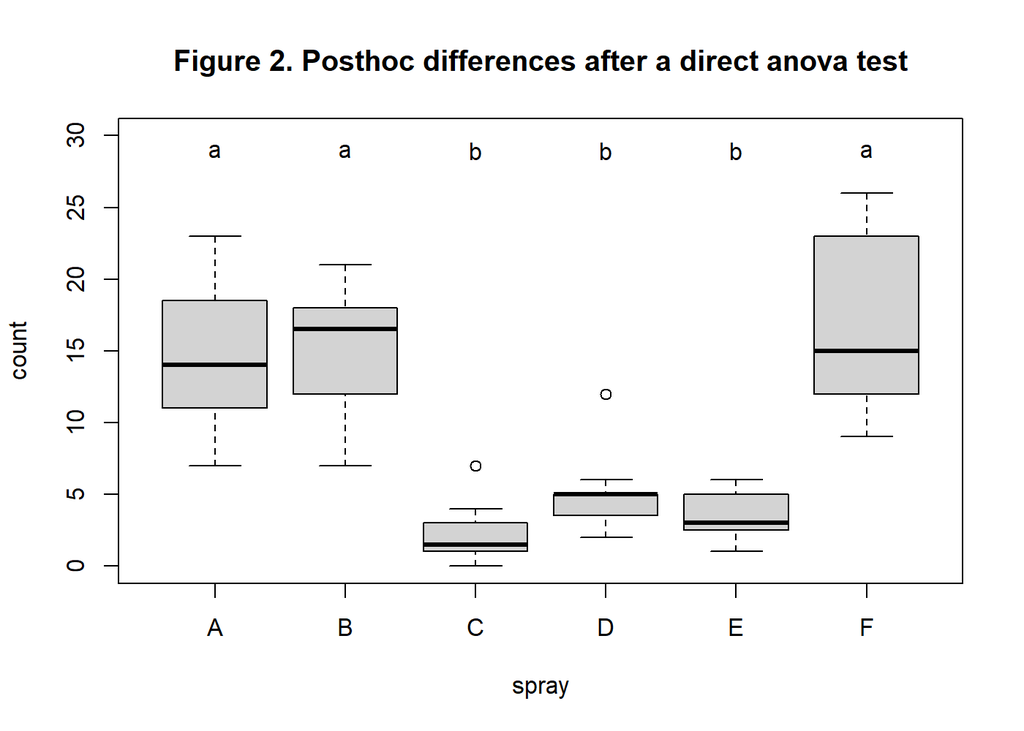

Figure 2. Posthoc differences after a direct anova test

```r
plot(count ~ spray, data = InsectSprays, ylim = c(0,30))
text(x = 1:6, y = 29, c("a", "a", "b", "b", "b", "a"))
title("Figure 2. Posthoc differences after a direct anova test")
```

## Exercice 4. Test for differences between sprays using non-parametric Kruskal-Wallis rank sum test.

## Again, redo the plot with these results. Use agricolae::kruskal().

```r
krus <- kruskal(InsectSprays$count, InsectSprays$spray)
print(krus)
```

```
## $statistics
##      Chisq Df      p.chisq  t.value      MSD
##   54.69134  5 1.510845e-10 1.996564 8.462804
##
## $parameters
##             test p.ajusted             name.t ntr alpha
##   Kruskal-Wallis      none InsectSprays$spray   6  0.05
##
## $means
##   InsectSprays.count     rank      std  r Min Max   Q25  Q50   Q75
## A          14.500000 52.16667 4.719399 12   7  23 11.50 14.0 17.75
## B          15.333333 54.83333 4.271115 12   7  21 12.50 16.5 17.50
## C           2.083333 11.45833 1.975225 12   0   7  1.00  1.5  3.00
## D           4.916667 25.58333 2.503028 12   2  12  3.75  5.0  5.00
## E           3.500000 19.33333 1.732051 12   1   6  2.75  3.0  5.00
## F          16.666667 55.62500 6.213378 12   9  26 12.50 15.0 22.50
##
## $comparison
## NULL
##
## $groups
##   InsectSprays$count groups
## F           55.62500      a
## B           54.83333      a
## A           52.16667      a
## D           25.58333      b
## E           19.33333     bc
## C           11.45833      c
##
## attr(,"class")
## [1] "group"
```

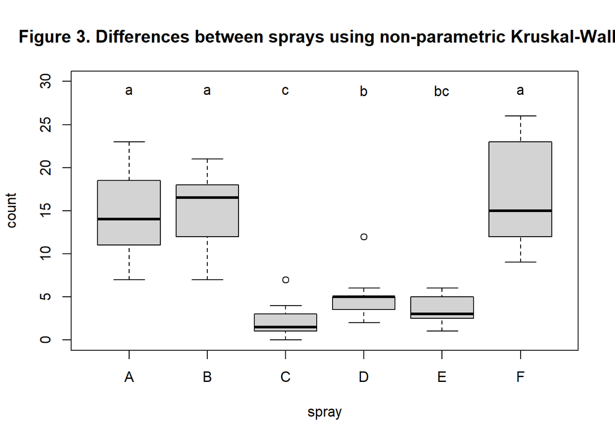

Figure 3. Differences between sprays using non-parametric Kruskal-Wallis

```r
plot(count ~ spray, data = InsectSprays, ylim = c(0,30))
text(x = 1:6, y = 29, c("a", "a", "c", "b", "bc", "a"))
title("Figure 3. Differences between sprays using non-parametric Kruskal-Wallis")
```

# Answer: This analysis between treatment C and D proved that the difference is significant.

## Exercice 5. Transform count data using sqrt(counts) and redo the anova, the Tukey posthoc comparison and the plot.

#sqrt(counts) and redo the anova

```r
res.aov2 <- aov(sqrt(count) ~ spray, data = InsectSprays)
summary(res.aov2)
```

```
##             Df Sum Sq Mean Sq F value Pr(>F)
## spray        5  88.44  17.688    44.8 <2e-16 ***
## Residuals   66  26.06   0.395
## ---
## Signif. codes:  0 '***' 0.001 '**' 0.01 '*' 0.05 '.' 0.1 ' ' 1
```

#Tukey posthoc comparison and the plot.

```r
tukey.test2 <- TukeyHSD(res.aov2)
print(tukey.test2)
```

```
##   Tukey multiple comparisons of means
##     95% family-wise confidence level
##
## Fit: aov(formula = sqrt(count) ~ spray, data = InsectSprays)
##
## $spray
##           diff        lwr        upr     p adj
## B-A  0.1159530 -0.6369601  0.8688661 0.9975245
## C-A -2.5158217 -3.2687349 -1.7629086 0.0000000
## D-A -1.5963245 -2.3492377 -0.8434114 0.0000006
## E-A -1.9512174 -2.7041305 -1.1983042 0.0000000
## F-A  0.2579388 -0.4949744  1.0108519 0.9144964
## C-B -2.6317747 -3.3846879 -1.8788616 0.0000000
## D-B -1.7122775 -2.4651907 -0.9593644 0.0000001
## E-B -2.0671704 -2.8200835 -1.3142572 0.0000000
## F-B  0.1419858 -0.6109274  0.8948989 0.9935788
## D-C  0.9194972  0.1665841  1.6724103 0.0080813
## E-C  0.5646043 -0.1883088  1.3175175 0.2512638
## F-C  2.7737605  2.0208474  3.5266736 0.0000000
## E-D -0.3548928 -1.1078060  0.3980203 0.7366389
## F-D  1.8542633  1.1013502  2.6071764 0.0000000
## F-E  2.2091561  1.4562430  2.9620693 0.0000000
```

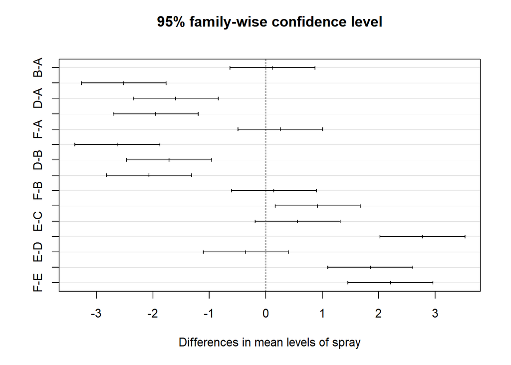

Figure 4. Tukey posthoc comparison

```r
plot(tukey.test2)
```

# Performing the agricolae test

```r
letter_test2 <- HSD.test(res.aov2, "spray")
letter_test2
```

```
## $statistics
##     MSerror Df     Mean      CV       MSD
##   0.3948178 66 2.812433 22.3417 0.7529131
##
## $parameters
##    test name.t ntr StudentizedRange alpha
##   Tukey  spray   6         4.150851  0.05
##
## $means
##   sqrt(count)       std  r      Min      Max      Q25      Q50      Q75
## A    3.760678 0.6243234 12 2.645751 4.795832 3.388646 3.741657 4.210363
## B    3.876631 0.5768841 12 2.645751 4.582576 3.533320 4.061553 4.182054
## C    1.244857 0.7630074 12 0.000000 2.645751 1.000000 1.207107 1.732051
## D    2.164354 0.5033405 12 1.414214 3.464102 1.933013 2.236068 2.236068
## E    1.809461 0.4963695 12 1.000000 2.449490 1.652591 1.732051 2.236068
## F    4.018617 0.7512773 12 3.000000 5.099020 3.533320 3.872983 4.742557
##
## $comparison
## NULL
##
## $groups
##   sqrt(count) groups
## F    4.018617      a
## B    3.876631      a
## A    3.760678      a
## D    2.164354      b
## E    1.809461     bc
## C    1.244857      c
##
## attr(,"class")
## [1] "group"
```

# putting up the plot

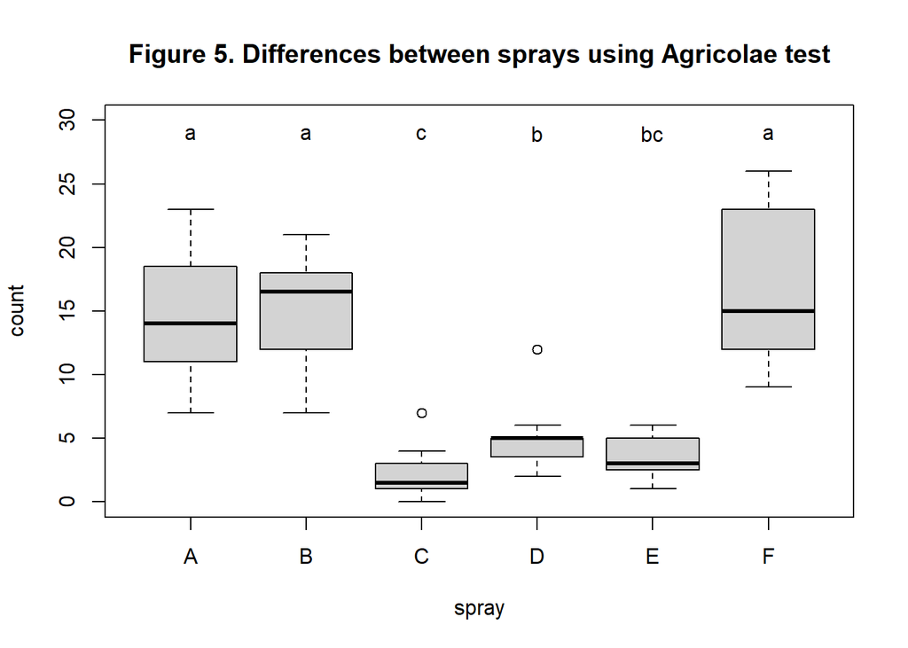

Figure 5. Differences between sprays using Agricolae test

```r
plot(count ~ spray, data = InsectSprays, ylim = c(0,30))
text(x = 1:6, y = 29, c("a", "a", "c", "b", "bc", "a"))
title("Figure 5. Differences between sprays using Agricolae test")
```

## Exercice 6. Test for normality of residuals for the two performed anova analyses of points 4 and 6 using shapiro.test()

# shapiro test for the 1 anova analysis

```r
shapiro.test(res.aov$residuals)
```

```
##
##  Shapiro-Wilk normality test
##
## data:  res.aov$residuals
## W = 0.96006, p-value = 0.02226
```

# conclusion: p < 0.05 => then the null hypothesis is rejected, there is no normality

# shapiro test for the 2 anova analysis

```r
shapiro.test(res.aov2$residuals)
```

```
##
##  Shapiro-Wilk normality test
##
## data:  res.aov2$residuals
## W = 0.98721, p-value = 0.6814
```

# conclusion: p > 0.05 => the null hypothesis is accepted, there is normality.

# Use plot the anova to see the qqplots and compare them.

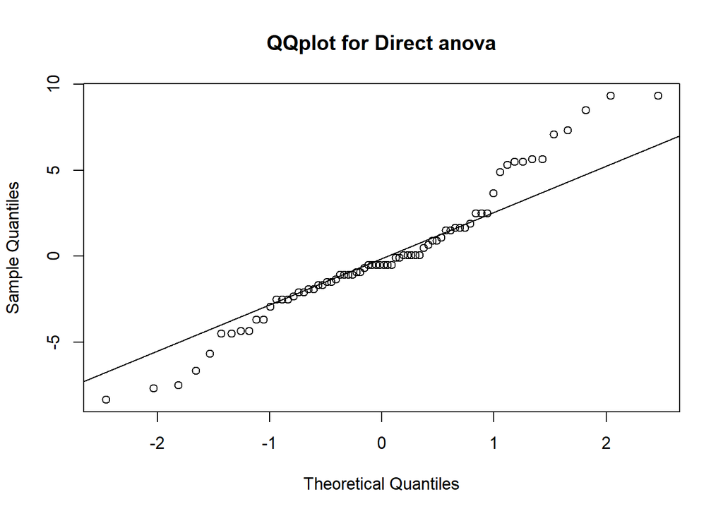

```r
qqnorm(res.aov$residuals, main = "QQplot for Direct anova")
qqline(res.aov$residuals)
```

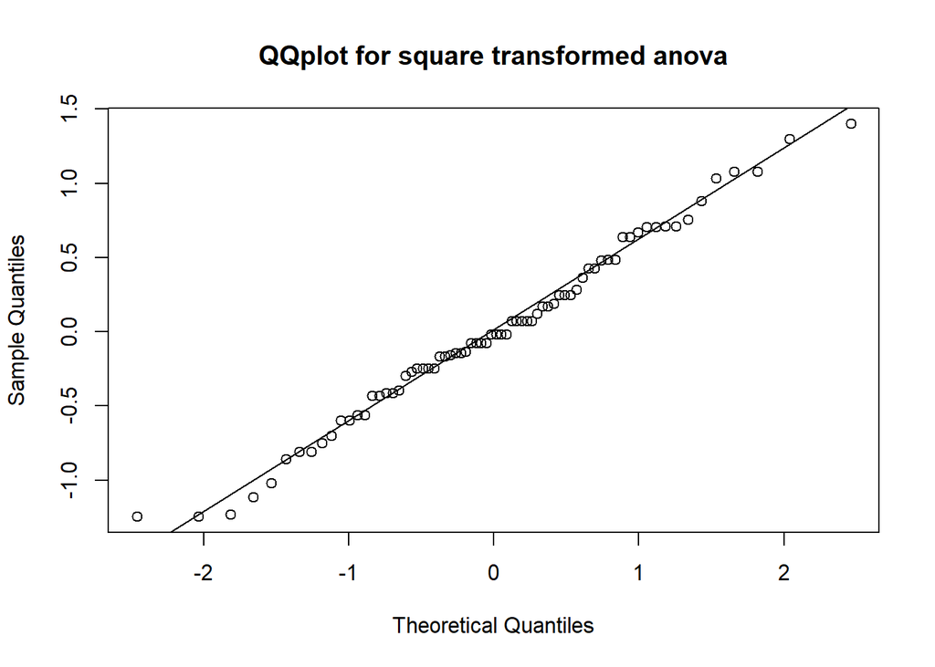

```r
qqnorm(res.aov2$residuals, main = "QQplot for square transformed anova")
qqline(res.aov2$residuals)
```

# The square transformed anova is closer to normality than the first one. In fact, in the qqplot the points are closer to the line than in the qqplot for the direct anova.

## Exercice 7. Which of the previous analysis is the adequate in this case? Why?

Previous analysis shown that square root anova is the adequate one. Because it facilitate the normality in transforming data.

Compare to direct anova it is more accurate in detecting significant differences between the treatments (e.g. C and D).

In addition, Kruskal-Wallis analysis was said to be relevant as it showcase the same differences as the square root anova.

### Is there any difference in the results between the square root transformed ANOVA and the Kruskal-Wallis analyses?

No, there was no difference observed.

### Is there any difference in the results between the direct ANOVA and the square root transformed ANOVA? Which ones?

Yes, some sort of discrepancies observed.In the spray C and D case, the square root transformed anova appeared to be statistically different while on direct anova, otherwise.

Moreover, there is no statistical difference between C and E, D and E for the both tests.